# Purchases and Sales

Tanya Bonilla

# Loading the data

First, we begin by loading the libraries and data that we will be tidying.

```r
library(tidyverse)
library(tidyr)
library(dplyr)

register <- read_csv("register.csv", na = "--")
sales <- read_csv("sales.csv")
```

# Getting to Know the Data

By analyzing the data, we can get an idea on how much the data defies Tidy Data principles.

## *Register data*

This data provides raw data collected by a new system that processes purchases made in the store.

There are 11 variables and 126 observations. Some issues that pertain to this column are that the column names are too lengthy and some have spaces in between. There is also the issue of missing data which we solved by filling in the dashes with N/A.

```r
colnames(register)
```

```
 [1] "purchase"
 [2] "item"
 [3] "charge"
 [4] "price"
 [5] "is the customer a student/faculty/staff (0) or unaffiliated (1)"
 [6] "customer id"
 [7] "receipt"
 [8] "contact preference"
 [9] "newsletter"
[10] "sales"
[11] "preferred customer discount"
```

```r
head(register)
```

| purchase | item | charge | price | is the customer a student/faculty/staff (0) or unaffiliated (1) | customer id | receipt | contact preference | newsletter | sales | preferred customer discount |
| --- | --- | --- | --- | --- | --- | --- | --- | --- | --- | --- |
| 1 | 396941 | cost | 50.00 | 0 | 4 | FALSE | email | TRUE | TRUE | TRUE |
| 1 | 396941 | tax | 0.50 | 0 | 4 | FALSE | email | TRUE | TRUE | TRUE |
| 2 | 528028 | cost | 20.99 | 1 | NA | TRUE | NA | NA | NA | NA |
| 2 | 528028 | tax | 0.30 | 1 | NA | TRUE | NA | NA | NA | NA |
| 2 | 396941 | cost | 50.00 | 1 | NA | TRUE | NA | NA | NA | NA |
| 2 | 396941 | tax | 0.50 | 1 | NA | TRUE | NA | NA | NA | NA |

## *Sales data*

The dataset is wide with 22 of the 23 column names are a combination of month and year spanning from 2018 to 2019 and the category of inventory goods.

```r
ncol(sales)
```

```
[1] 23
```

```r
nrow(sales)
```

```
[1] 8
```

```r
colnames(sales)
```

```
 [1] "category of inventory goods" "1-2018"                      "2-2018"
 [4] "3-2018"                      "4-2018"                      "5-2018"
 [7] "6-2018"                      "7-2018"                      "8-2018"
[10] "9-2018"                      "10-2018"                     "11-2018"
[13] "12-2018"                     "1-2019"                      "2-2019"
[16] "3-2019"                      "4-2019"                      "5-2019"
[19] "6-2019"                      "7-2019"                      "8-2019"
[22] "9-2019"                      "10-2019"
```

```r
head(sales)
```

| category of inventory goods | 1-2018 | 2-2018 | 3-2018 | 4-2018 | 5-2018 | 6-2018 | 7-2018 | 8-2018 | 9-2018 | 10-2018 | 11-2018 | 12-2018 | 1-2019 | 2-2019 | 3-2019 | 4-2019 | 5-2019 | 6-2019 | 7-2019 | 8-2019 | 9-2019 | 10-2019 |
| --- | --- | --- | --- | --- | --- | --- | --- | --- | --- | --- | --- | --- | --- | --- | --- | --- | --- | --- | --- | --- | --- | --- |
| food | 10.6 | 11.01 | 15.5 | 16.6 | 12.8 | 4.13 | 2.8 | 5 | 8.25 | 9.2 | 10.35 | 6.4 | 10.8 | 12.3 | 14.9 | 16 | 15 | 5.3 | 4.02 | 3.14 | 8.5 | 5.6 |
| drinks | 8.0 | 9.00 | 13.0 | 19.0 | 24.0 | 7.00 | 6.0 | 10 | 12.00 | 12.0 | 8.00 | 4.0 | 9.0 | 9.0 | 12.0 | 19 | 25 | 10.0 | 8.00 | 9.00 | 11.0 | 8.0 |
| textbooks | 105.0 | 135.00 | 20.0 | 11.0 | 21.0 | 7.00 | 3.0 | 250 | 100.00 | 15.0 | 13.00 | 5.0 | 111.0 | 129.0 | 13.0 | 10 | 10 | 8.0 | 4.00 | 239.00 | 99.0 | 21.0 |
| supplies | 8.0 | 13.00 | 4.0 | 11.0 | 4.0 | 15.00 | 11.0 | 10 | 17.00 | 17.0 | 16.00 | 10.0 | 16.0 | 10.0 | 20.0 | 10 | 7 | 8.0 | 2.00 | 10.00 | 10.0 | 8.0 |
| apparel | 17.0 | 8.00 | 7.0 | 10.0 | 15.0 | 18.00 | 3.0 | 9 | 3.00 | 3.0 | 17.00 | 16.0 | 9.0 | 16.0 | 3.0 | 10 | 13 | 12.0 | 20.00 | 2.00 | 9.0 | 6.0 |
| accessories | 6.0 | 7.00 | 12.0 | 6.0 | 20.0 | 15.00 | 20.0 | 10 | 12.00 | 8.0 | 5.00 | 13.0 | 14.0 | 3.0 | 2.0 | 18 | 9 | 7.0 | 11.00 | 17.00 | 18.0 | 5.0 |

# Cleaning and Tidying

## *Register* data

The first thing that I tackled in the register data set is change the column names that seemed too lengthy or ambiguous.

```r
colnames(register)[colnames(register) == "is the customer a student/faculty/staff (0) or unaffiliated (1)"]  <- "customer_type"
colnames(register)[colnames(register) == "sales"]  <- "notifications"
colnames(register)[colnames(register) == "customer id"]  <- "customer_id"
colnames(register)[colnames(register) == "contact preference"]  <- "contact_preference"
colnames(register)[colnames(register) == "preferred customer discount"]  <- "customer_discount"
```

Then, we convert *customer_type* to a logical type as it is easier to understand than 0 and 1. We, also, change the categorical *contact_preference* variable to discrete data, so it is easier to visualize down the line; we do the same to *charge*.

```r
register$customer_type <- as.logical(as.integer(register$customer_type))
register$contact_preference <- as_factor(register$contact_preference)
levels(register$contact_preference)
```

```
[1] "email" "mail"  "fax"
```

```r
register$charge <- as_factor(register$charge)
levels(register$charge)
```

```
[1] "cost" "tax"
```

We can see that the **register** table has a lot of information. There is enough infromation about two separate entities that can allow us to separate the table into two; **Checkout** and **Customer**.

## *Checkout*

Checkout will consist of data that pertains to purchases processsed sans any customer data besides *customer_id*. The purpose of keeping that variable is so we have a way to connect connect any customer information to their purchase.

```r
checkout <- tibble(purchase = register$purchase,
                   receipt = register$receipt,
                   item = register$item,
                   charge = register$charge,
                   price = register$price,
                   customer_id = register$customer_id
                   )
```

**Checkout** will contain:

```r
colnames(checkout)
```

```
[1] "purchase"    "receipt"     "item"        "charge"      "price"       "customer_id"
```

## *Customer*

Customer will consist of information available based on the customer. We also get rid of any redudant or duplicated data with **distinct()** and omit any missing data.

```r
customer <- tibble(customer_id = register$customer_id,
                   customer_type = register$customer_type,
                   customer_discount = register$customer_discount,
                   newsletter = register$newsletter,
                   notifications = register$notifications,
                   contact_preference = register$contact_preference
                   )
customer <- distinct(customer) %>% na.omit(customer)
```

Customer will consist of:

```r
colnames(customer)
```

```
[1] "customer_id"        "customer_type"      "customer_discount"  "newsletter"
[5] "notifications"      "contact_preference"
```

## *Sales* data

Now, we tackle **sales**. We begin by changing the *category of inventory good* variable to *category_of_goods* to make it less lengthy and it is all connected. **Sales** is a wide table and we want to make it longer by converting columns 2 to 23 to *month* and *year*.

```r
colnames(sales)[colnames(sales) == "category of inventory goods"]  <- "category_of_goods"
sales <- gather(sales, month, sale, 2:23)
sales <- separate(sales, month, into = c("month", "year"), sep = "-")
sales$category_of_goods <- as_factor(sales$category_of_goods)
levels(sales$category_of_goods)
```

```
[1] "food"                        "drinks"                      "textbooks"
[4] "supplies"                    "apparel"                     "accessories"
[7] "electronics"                 "health, beauty, and fitness"
```

# Visualizations

```r
library(ggplot2)
cust_v <- ggplot(customer, aes(x= contact_preference)) + geom_histogram(stat= "count")
```

```
Ignoring unknown parameters: binwidth, bins, pad
```

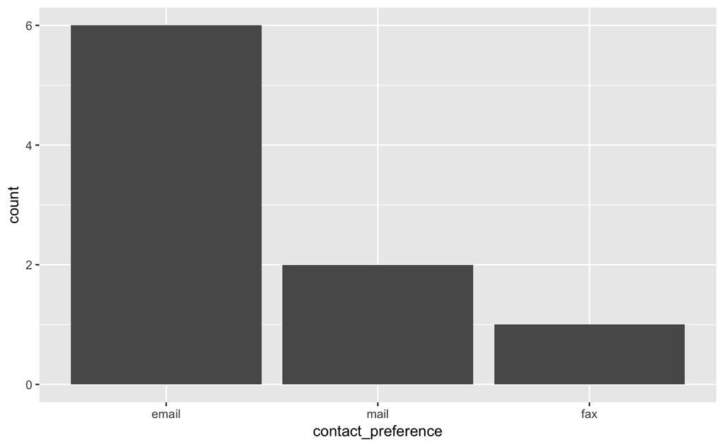

```r
cust_v
```